# Practical Machine Learning Course Project

Paolo Flaim

15 ottobre 2018

## Executive summary

The goal of the project is to predict how well an exercise is done. All the data are available are coming from sensor appliend on the body and available in the [Human Activity Recognition](http://web.archive.org/web/20161224072740/http:/groupware.les.inf.puc-rio.br/har) archive. The data are labeled and the “classe” variable rapresent the outcome. After a data cleaning process we have used only the useful variables to train and choose the best model. Finally we choose the model trained with the method “Random forest”, because it result the best in accuracy (99%) and have applied the prediction on the test dataset.

### Data Description

Using devices such as Jawbone Up, Nike FuelBand, and Fitbit it is now possible to collect a large amount of data about personal activity relatively inexpensively. These type of devices are part of the quantified self movement – a group of enthusiasts who take measurements about themselves regularly to improve their health, to find patterns in their behavior, or because they are tech geeks. One thing that people regularly do is quantify how much of a particular activity they do, but they rarely quantify how well they do it. In this project, your goal will be to use data from accelerometers on the belt, forearm, arm, and dumbell of 6 participants. They were asked to perform barbell lifts correctly and incorrectly in 5 different ways.

### Data loading

Downloading the dataset.

```r
library(caret)
library(rattle)

trainingDataUrl <- "https://d396qusza40orc.cloudfront.net/predmachlearn/pml-training.csv"
trainingData <- read.csv(trainingDataUrl, header=TRUE, sep=",", stringsAsFactors = TRUE)
testingDataUrl <- "https://d396qusza40orc.cloudfront.net/predmachlearn/pml-testing.csv"
testingData <- read.csv(testingDataUrl, header=TRUE, sep=",", stringsAsFactors = TRUE)
```

- Training dataset contains `19622` observations
- Testing dataset contains `20` observations

### Data Cleaning

Removing of all columns not useful for training the model (i.e. missing or not complete data)

```r
#check not significant columns
columnCheck <- sapply(trainingData, function(x){sum(is.na(x) | x == "") < nrow(trainingData)*0.1 })
#remove not significant columns
trainDataClean <- trainingData[, columnCheck]
trainDataClean <- trainDataClean[, -c(1:7)]
#dim(trainDataClean)

testDataClean <- testingData[, columnCheck]
#dim(testDataClean)
```

The datasets contains only `53` useful variables (instead of all `160` variables).

### Data partition

Preparation of the partition for the training data.

```r
set.seed(1234)
partition <- createDataPartition(trainDataClean$classe, p = 0.6, list=FALSE)
train <- trainDataClean[partition,]
train.test <- trainDataClean[-partition,]
```

### Model Training

It is used a cross-validation with n=5 to improve the results.

```r
trainControl <- trainControl(method="cv", number=5)
```

#### Train with Classification tree method

[figure not shown]

```r
fit.ct <- train(classe~., data=train, method="rpart", trControl=trainControl)
fancyRpartPlot(fit.ct$finalModel)
```

Confusion matrix report:

```r
fit.ct.test <- predict(fit.ct, newdata = train.test)
confusionMatrix.fit.ct <- confusionMatrix(train.test$classe,fit.ct.test)
confusionMatrix.fit.ct
```

```
## Confusion Matrix and Statistics
##
##           Reference
## Prediction    A    B    C    D    E
##          A 2029   44  155    0    4
##          B  638  505  375    0    0
##          C  644   49  675    0    0
##          D  567  232  487    0    0
##          E  209  211  383    0  639
##
## Overall Statistics
##
##                Accuracy : 0.4904
##                  95% CI : (0.4793, 0.5016)
##     No Information Rate : 0.5209
##     P-Value [Acc > NIR] : 1
##
##                   Kappa : 0.3339
##  Mcnemar's Test P-Value : NA
##
## Statistics by Class:
##
##                      Class: A Class: B Class: C Class: D Class: E
## Sensitivity            0.4965  0.48511  0.32530       NA  0.99378
## Specificity            0.9460  0.85114  0.87992   0.8361  0.88852
## Pos Pred Value         0.9091  0.33267  0.49342       NA  0.44313
## Neg Pred Value         0.6334  0.91530  0.78388       NA  0.99938
## Prevalence             0.5209  0.13268  0.26447   0.0000  0.08195
## Detection Rate         0.2586  0.06436  0.08603   0.0000  0.08144
## Detection Prevalence   0.2845  0.19347  0.17436   0.1639  0.18379
## Balanced Accuracy      0.7212  0.66812  0.60261       NA  0.94115
```

Method accuracy:

```r
confusionMatrix.fit.ct$overall[1]
```

```
## Accuracy
## 0.490441
```

#### Train with Random Forest method

```r
fit.rf <- train(classe~., data=train, method="rf", trControl=trainControl, verbose=FALSE)
print(fit.rf)
```

```
## Random Forest
##
## 11776 samples
##    52 predictor
##     5 classes: 'A', 'B', 'C', 'D', 'E'
##
## No pre-processing
## Resampling: Cross-Validated (5 fold)
## Summary of sample sizes: 9420, 9421, 9421, 9421, 9421
## Resampling results across tuning parameters:
##
##   mtry  Accuracy   Kappa
##    2    0.9884514  0.9853890
##   27    0.9887062  0.9857119
##   52    0.9829318  0.9784059
##
## Accuracy was used to select the optimal model using the largest value.
## The final value used for the model was mtry = 27.
```

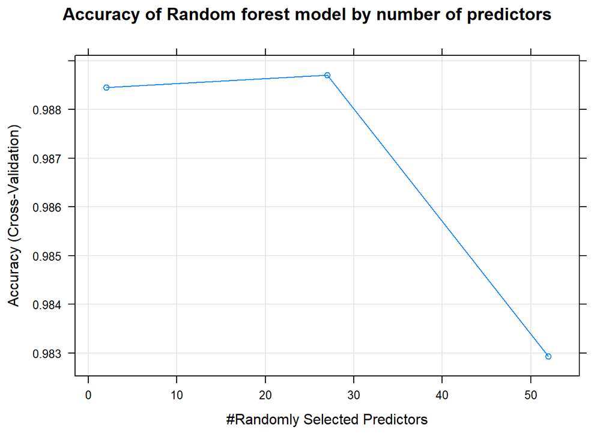

```r
plot(fit.rf,main="Accuracy of Random forest model by number of predictors")
```

Confusion matrix report:

```r
fit.rf.test <- predict(fit.rf, newdata = train.test)
confusionMatrix.fit.rf <- confusionMatrix(train.test$classe,fit.rf.test)
confusionMatrix.fit.rf
```

```
## Confusion Matrix and Statistics
##
##           Reference
## Prediction    A    B    C    D    E
##          A 2231    0    1    0    0
##          B   19 1492    7    0    0
##          C    0   13 1348    7    0
##          D    0    1   21 1262    2
##          E    0    2    2    4 1434
##
## Overall Statistics
##
##                Accuracy : 0.9899
##                  95% CI : (0.9875, 0.992)
##     No Information Rate : 0.2868
##     P-Value [Acc > NIR] : < 2.2e-16
##
##                   Kappa : 0.9873
##  Mcnemar's Test P-Value : NA
##
## Statistics by Class:
##
##                      Class: A Class: B Class: C Class: D Class: E
## Sensitivity            0.9916   0.9894   0.9775   0.9914   0.9986
## Specificity            0.9998   0.9959   0.9969   0.9963   0.9988
## Pos Pred Value         0.9996   0.9829   0.9854   0.9813   0.9945
## Neg Pred Value         0.9966   0.9975   0.9952   0.9983   0.9997
## Prevalence             0.2868   0.1922   0.1758   0.1622   0.1830
## Detection Rate         0.2843   0.1902   0.1718   0.1608   0.1828
## Detection Prevalence   0.2845   0.1935   0.1744   0.1639   0.1838
## Balanced Accuracy      0.9957   0.9926   0.9872   0.9939   0.9987
```

Method accuracy:

```r
confusionMatrix.fit.rf$overall[1]
```

```
##  Accuracy
## 0.9899312
```

Most important variables:

```r
variableImportance.rf <- varImp(fit.rf)
variableImportance.rf
```

```
## rf variable importance
##
##   only 20 most important variables shown (out of 52)
##
##                      Overall
## roll_belt             100.00
## pitch_forearm          60.65
## yaw_belt               57.16
## magnet_dumbbell_y      45.86
## pitch_belt             44.46
## roll_forearm           42.61
## magnet_dumbbell_z      41.53
## accel_dumbbell_y       22.05
## roll_dumbbell          18.17
## magnet_belt_z          16.41
## accel_forearm_x        16.37
## magnet_dumbbell_x      16.35
## total_accel_dumbbell   13.90
## accel_dumbbell_z       13.74
## magnet_forearm_z       13.21
## accel_belt_z           13.18
## magnet_belt_y          13.16
## yaw_arm                11.50
## gyros_belt_z           10.97
## magnet_belt_x          10.05
```

#### Train with Gradient Boosting method

```r
fit.gbm <- train(classe~., data=train, method="gbm", trControl=trainControl, verbose=FALSE)
print(fit.gbm)
```

```
## Stochastic Gradient Boosting
##
## 11776 samples
##    52 predictor
##     5 classes: 'A', 'B', 'C', 'D', 'E'
##
## No pre-processing
## Resampling: Cross-Validated (5 fold)
## Summary of sample sizes: 9421, 9421, 9421, 9420, 9421
## Resampling results across tuning parameters:
##
##   interaction.depth  n.trees  Accuracy   Kappa
##   1                   50      0.7472823  0.6797349
##   1                  100      0.8193774  0.7715328
##   1                  150      0.8521570  0.8130493
##   2                   50      0.8532604  0.8141164
##   2                  100      0.9075237  0.8830213
##   2                  150      0.9314704  0.9132778
##   3                   50      0.8994565  0.8727669
##   3                  100      0.9430199  0.9279196
##   3                  150      0.9597490  0.9490835
##
## Tuning parameter 'shrinkage' was held constant at a value of 0.1
##
## Tuning parameter 'n.minobsinnode' was held constant at a value of 10
## Accuracy was used to select the optimal model using the largest value.
## The final values used for the model were n.trees = 150,
##  interaction.depth = 3, shrinkage = 0.1 and n.minobsinnode = 10.
```

Confusion matrix report:

```r
fit.gbm.test <- predict(fit.gbm, newdata = train.test)
confusionMatrix.fit.gbm <- confusionMatrix(train.test$classe,fit.gbm.test)
confusionMatrix.fit.gbm
```

```
## Confusion Matrix and Statistics
##
##           Reference
## Prediction    A    B    C    D    E
##          A 2209   16    3    3    1
##          B   52 1422   40    1    3
##          C    0   49 1292   24    3
##          D    1    9   41 1230    5
##          E    2   26   15   16 1383
##
## Overall Statistics
##
##                Accuracy : 0.9605
##                  95% CI : (0.9559, 0.9647)
##     No Information Rate : 0.2886
##     P-Value [Acc > NIR] : < 2.2e-16
##
##                   Kappa : 0.95
##  Mcnemar's Test P-Value : 1.568e-10
##
## Statistics by Class:
##
##                      Class: A Class: B Class: C Class: D Class: E
## Sensitivity            0.9757   0.9343   0.9288   0.9655   0.9914
## Specificity            0.9959   0.9848   0.9882   0.9915   0.9909
## Pos Pred Value         0.9897   0.9368   0.9444   0.9565   0.9591
## Neg Pred Value         0.9902   0.9842   0.9847   0.9933   0.9981
## Prevalence             0.2886   0.1940   0.1773   0.1624   0.1778
## Detection Rate         0.2815   0.1812   0.1647   0.1568   0.1763
## Detection Prevalence   0.2845   0.1935   0.1744   0.1639   0.1838
## Balanced Accuracy      0.9858   0.9596   0.9585   0.9785   0.9911
```

Method accuracy:

```r
confusionMatrix.fit.gbm$overall[1]
```

```
##  Accuracy
## 0.9604894
```

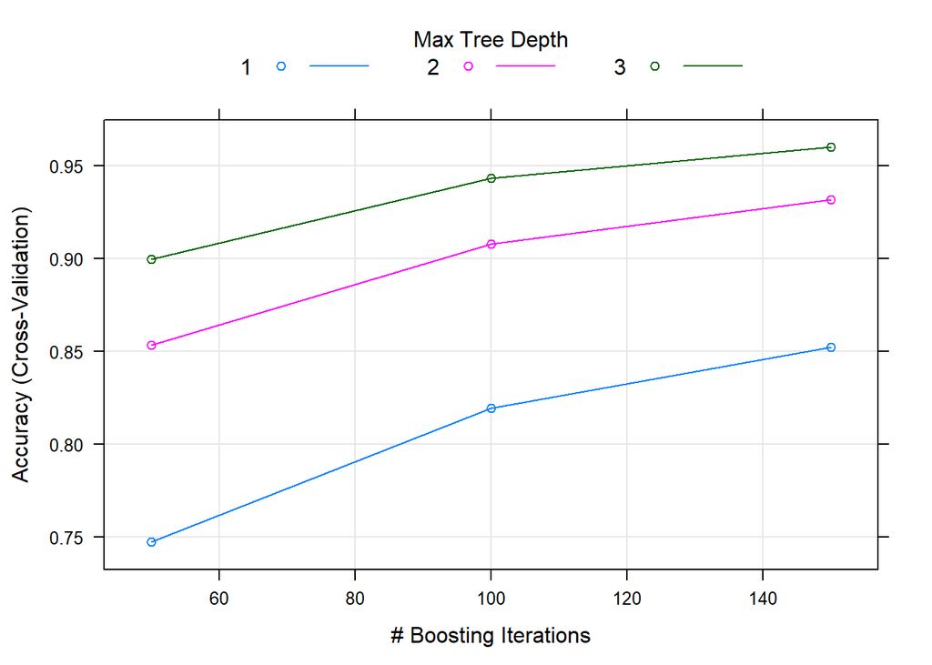

```r
plot(fit.gbm)
```

### Prediction

The selected model is applied on the test set:

```r
pred.rf.test <- predict(fit.rf, newdata = testDataClean)
pred.rf.test
```

```
##  [1] B A B A A E D B A A B C B A E E A B B B
## Levels: A B C D E
```